# Part I - Data Exploration for PISA 2012 dataset

## Introduction

The Program for International Student Assessment (PISA) is the global survey developed by the Organization for Economic Co-operation and Development (OECD) to assess the competencies of 15-year-old students in reading, mathematics and science, as well as to understand their family backgrounds and educational systems. Around 510,000 students in 65 countries and economies participated in PISA 2012. Of those countries and economies, 44 took part in an assessment of creative problem-solving and 18 were evaluated in financial literacy.

## Preliminary Wrangling

```python
# import all packages and set plots to be embedded inline
import pandas as pd
import numpy as np
import matplotlib.pyplot as plt
%matplotlib inline
import seaborn as sb
```

### Download & Load dataset

- The PISA zip file (325 MB) is provided on the Udacity learning site [HERE](https://www.google.com/url?q=https://s3.amazonaws.com/udacity-hosted-downloads/ud507/pisa2012.csv.zip&sa=D&ust=1581581520574000).
- Extract the zip file above, we have a csv file (2.75 GB) named *pisa2012.csv*.
- Details about the data dictionary can be found [HERE](https://www.google.com/url?q=https://s3.amazonaws.com/udacity-hosted-downloads/ud507/pisadict2012.csv&sa=D&ust=1554482573645000).

```python
df = pd.read_csv('D:/COURSE/Nanodegree Udacity/Data Analyst/Course Projects/Project 5/pisa2012.csv', encoding='latin-1')
df.head()
```

|  | Unnamed: 0 | CNT | SUBNATIO | STRATUM | OECD | NC | SCHOOLID | STIDSTD | ST01Q01 | ST02Q01 | ... | W_FSTR75 | W_FSTR76 | W_FSTR77 | W_FSTR78 | W_FSTR79 | W_FSTR80 | WVARSTRR | VAR_UNIT | SENWGT_STU | VER_STU |
| --- | --- | --- | --- | --- | --- | --- | --- | --- | --- | --- | --- | --- | --- | --- | --- | --- | --- | --- | --- | --- | --- |
| 0 | 1 | Albania | 80000 | ALB0006 | Non-OECD | Albania | 1 | 1 | 10 | 1.0 | ... | 13.7954 | 13.9235 | 13.1249 | 13.1249 | 4.3389 | 13.0829 | 19 | 1 | 0.2098 | 22NOV13 |
| 1 | 2 | Albania | 80000 | ALB0006 | Non-OECD | Albania | 1 | 2 | 10 | 1.0 | ... | 13.7954 | 13.9235 | 13.1249 | 13.1249 | 4.3389 | 13.0829 | 19 | 1 | 0.2098 | 22NOV13 |
| 2 | 3 | Albania | 80000 | ALB0006 | Non-OECD | Albania | 1 | 3 | 9 | 1.0 | ... | 12.7307 | 12.7307 | 12.7307 | 12.7307 | 4.2436 | 12.7307 | 19 | 1 | 0.1999 | 22NOV13 |
| 3 | 4 | Albania | 80000 | ALB0006 | Non-OECD | Albania | 1 | 4 | 9 | 1.0 | ... | 12.7307 | 12.7307 | 12.7307 | 12.7307 | 4.2436 | 12.7307 | 19 | 1 | 0.1999 | 22NOV13 |
| 4 | 5 | Albania | 80000 | ALB0006 | Non-OECD | Albania | 1 | 5 | 9 | 1.0 | ... | 12.7307 | 12.7307 | 12.7307 | 12.7307 | 4.2436 | 12.7307 | 19 | 1 | 0.1999 | 22NOV13 |

5 rows × 636 columns

```python
df.shape
```

```
(485490, 636)
```

### Dataset structure

The *pisa2012.csv* file has 485,490 student records grouped in 636 columns.

The dataset contains the results from exams in mathematics, science, reading, financial literacy as well as students' demographic, family backgrounds, study and out-of-school time, learning methods, school and home ICT facilities, language spoken at home, students' interests and moviations, and more.

### Main features of interest

The main features of this dataset are plausible values for mathematics, science and reading along with 3 learning time columns. According to the PISA 2012 Technical Report [(LINK)](https://www.oecd.org/pisa/pisaproducts/PISA%202012%20Technical%20Report_Chapter%209.pdf), these plausible values are not real test scores but random numbers drawn from the distribution of scores that could reasonably assigned to each individual. Various factors can affect these test scores, so it's best to take the average across each subgroup.

### Features in the dataset that can support my investigation

In this project, I want to know if any factors can influence the academic performance of students and their study time. Due to the complexity of the dataset, I only keep some features of interest as below to investigate:

- Country of residence
- OECD membership
- Student's gender
- Parents' education level
- 3 values for learning time (minutes per week) in each subject category
- 5 plausible values in each subject category

```python
# List of variables of interest
var_interest = [
    'CNT', 'OECD', 'ST04Q01', 'FISCED', 'MISCED', 'MMINS', 'SMINS', 'LMINS',
    'PV1MATH', 'PV2MATH', 'PV3MATH', 'PV4MATH', 'PV5MATH',
    'PV1READ', 'PV2READ', 'PV3READ', 'PV4READ', 'PV5READ',
    'PV1SCIE', 'PV2SCIE', 'PV3SCIE', 'PV4SCIE','PV5SCIE']

df_edited = df.filter(var_interest)
df_edited.head()
```

|  | CNT | OECD | ST04Q01 | FISCED | MISCED | MMINS | SMINS | LMINS | PV1MATH | PV2MATH | ... | PV1READ | PV2READ | PV3READ | PV4READ | PV5READ | PV1SCIE | PV2SCIE | PV3SCIE | PV4SCIE | PV5SCIE |
| --- | --- | --- | --- | --- | --- | --- | --- | --- | --- | --- | --- | --- | --- | --- | --- | --- | --- | --- | --- | --- | --- |
| 0 | Albania | Non-OECD | Female | ISCED 3A, ISCED 4 | ISCED 3A, ISCED 4 | NaN | NaN | NaN | 406.8469 | 376.4683 | ... | 249.5762 | 254.3420 | 406.8496 | 175.7053 | 218.5981 | 341.7009 | 408.8400 | 348.2283 | 367.8105 | 392.9877 |
| 1 | Albania | Non-OECD | Female | ISCED 3A, ISCED 4 | ISCED 5A, 6 | 270.0 | 90.0 | 315.0 | 486.1427 | 464.3325 | ... | 406.2936 | 349.8975 | 400.7334 | 369.7553 | 396.7618 | 548.9929 | 471.5964 | 471.5964 | 443.6218 | 454.8116 |
| 2 | Albania | Non-OECD | Female | ISCED 5A, 6 | ISCED 5A, 6 | NaN | NaN | 300.0 | 533.2684 | 481.0796 | ... | 401.2100 | 404.3872 | 387.7067 | 431.3938 | 401.2100 | 499.6643 | 428.7952 | 492.2044 | 512.7191 | 499.6643 |
| 3 | Albania | Non-OECD | Female | ISCED 5A, 6 | ISCED 3B, C | 135.0 | 90.0 | 135.0 | 412.2215 | 498.6836 | ... | 547.3630 | 481.4353 | 461.5776 | 425.0393 | 471.9036 | 438.6796 | 481.5740 | 448.9370 | 474.1141 | 426.5573 |
| 4 | Albania | Non-OECD | Female | ISCED 3A, ISCED 4 | None | NaN | NaN | NaN | 381.9209 | 328.1742 | ... | 311.7707 | 141.7883 | 293.5015 | 272.8495 | 260.1405 | 361.5628 | 275.7740 | 372.7527 | 403.5248 | 422.1746 |

5 rows × 23 columns

### Data Assessment

```python
df_edited.info()
```

```
<class 'pandas.core.frame.DataFrame'>
RangeIndex: 485490 entries, 0 to 485489
Data columns (total 23 columns):
 #   Column   Non-Null Count   Dtype
---  ------   --------------   -----
 0   CNT      485490 non-null  object
 1   OECD     485490 non-null  object
 2   ST04Q01  485490 non-null  object
 3   FISCED   452903 non-null  object
 4   MISCED   467085 non-null  object
 5   MMINS    283303 non-null  float64
 6   SMINS    270914 non-null  float64
 7   LMINS    282866 non-null  float64
 8   PV1MATH  485490 non-null  float64
 9   PV2MATH  485490 non-null  float64
 10  PV3MATH  485490 non-null  float64
 11  PV4MATH  485490 non-null  float64
 12  PV5MATH  485490 non-null  float64
 13  PV1READ  485490 non-null  float64
 14  PV2READ  485490 non-null  float64
 15  PV3READ  485490 non-null  float64
 16  PV4READ  485490 non-null  float64
 17  PV5READ  485490 non-null  float64
 18  PV1SCIE  485490 non-null  float64
 19  PV2SCIE  485490 non-null  float64
 20  PV3SCIE  485490 non-null  float64
 21  PV4SCIE  485490 non-null  float64
 22  PV5SCIE  485490 non-null  float64
dtypes: float64(18), object(5)
memory usage: 85.2+ MB
```

After filtering, there are only 23 columns now. Noticed that there are nulls in columns about learning time and parents' educational levels. Also, the data type of 2 education columns should be *categorical*, instead of *string*.

The OECD website states that there are 65 countries and economies participating in the test [(LINK)](https://www.oecd.org/pisa/aboutpisa/pisa-2012-participants.htm), so I want to check this in the dataset.

```python
# Check the number of countries
df_edited['CNT'].value_counts()
```

```
Mexico                      33806
Italy                       31073
Spain                       25313
Canada                      21544
Brazil                      19204
                            ...
Florida (USA)                1896
Perm(Russian Federation)     1761
Massachusetts (USA)          1723
Connecticut (USA)            1697
Liechtenstein                 293
Name: CNT, Length: 68, dtype: int64
```

There are 68 values here. In fact, at the bottom of the result above, *Florida (USA), Massachusetts (USA) and Connecticut (USA)* should be merged into 1. The OECD website [(LINK)](https://www.oecd.org/pisa/aboutpisa/pisa-2012-participants.htm) mentions only *United States*, so let's check if *United States* is in the dataset.

```python
# Check if United States is in the dataset
df_edited[df_edited['CNT'].str.contains('United States')]['CNT'].value_counts()
```

```
United States of America    4978
Name: CNT, dtype: int64
```

Noted that it is *United States of America*, so we need to merge 3 states into this one.

```python
df_edited['OECD'].value_counts()
```

```
OECD        295416
Non-OECD    190074
Name: OECD, dtype: int64
```

```python
# Check the education level of father
df_edited['FISCED'].value_counts()
```

```
ISCED 3A, ISCED 4    118890
ISCED 5A, 6          113406
ISCED 2               66728
ISCED 5B              61617
ISCED 3B, C           39789
ISCED 1               35938
None                  16535
Name: FISCED, dtype: int64
```

```python
# Check the educational level of mother
df_edited['MISCED'].value_counts()
```

```
ISCED 3A, ISCED 4    126768
ISCED 5A, 6          114452
ISCED 5B              68219
ISCED 2               66650
ISCED 1               36556
ISCED 3B, C           35672
None                  18768
Name: MISCED, dtype: int64
```

These columns have nulls (None). Also, values should be converted to *categorical* and replaced by more descriptive names.

### Data Cleaning

There are a few things we need to do here:

1. Replace *Florida (USA), Massachusetts (USA) and Connecticut (USA)* by *United States*
2. Add 3 columns that take the average of 5 plausible values for each subject category
3. Add a total score column, then remove those 15 plausible score columns
4. Rename all columns
5. Add a total learning time column
6. For parents' education columns, replaced values by more descriptive names, then convert them to categorical data type

```python
# Make a copy of the original dataset
df_copy = df_edited.copy()
```

#### #1. Replace *Florida (USA), Massachusetts (USA) and Connecticut (USA)* by *United States of America*

```python
states = ['Florida (USA)', 'Massachusetts (USA)', 'Connecticut (USA)']
df_copy['CNT'].replace(states, 'United States of America', inplace=True)
```

```python
# Should be empty
df_copy.query('CNT == @states')
```

|  | CNT | OECD | ST04Q01 | FISCED | MISCED | MMINS | SMINS | LMINS | PV1MATH | PV2MATH | ... | PV1READ | PV2READ | PV3READ | PV4READ | PV5READ | PV1SCIE | PV2SCIE | PV3SCIE | PV4SCIE | PV5SCIE |
| --- | --- | --- | --- | --- | --- | --- | --- | --- | --- | --- | --- | --- | --- | --- | --- | --- | --- | --- | --- | --- | --- |

0 rows × 23 columns

```python
# Check the number of participants, should be 65
df_copy['CNT'].value_counts()
```

```
Mexico                      33806
Italy                       31073
Spain                       25313
Canada                      21544
Brazil                      19204
                            ...
Latvia                       4306
New Zealand                  4291
Iceland                      3508
Perm(Russian Federation)     1761
Liechtenstein                 293
Name: CNT, Length: 65, dtype: int64
```

#### #2. Add 3 columns that take the average of 5 plausible values for each subject category

```python
# Add 3 average columns for each subject category
df_copy['math_score'] = np.mean(df_copy[['PV1MATH', 'PV2MATH', 'PV3MATH', 'PV4MATH', 'PV5MATH']], axis=1)
df_copy['reading_score'] = np.mean(df_copy[['PV1READ', 'PV2READ', 'PV3READ', 'PV4READ', 'PV5READ']], axis=1)
df_copy['science_score'] = np.mean(df_copy[['PV1SCIE' , 'PV2SCIE', 'PV3SCIE', 'PV4SCIE','PV5SCIE']], axis=1)

df_copy.head()
```

|  | CNT | OECD | ST04Q01 | FISCED | MISCED | MMINS | SMINS | LMINS | PV1MATH | PV2MATH | ... | PV4READ | PV5READ | PV1SCIE | PV2SCIE | PV3SCIE | PV4SCIE | PV5SCIE | math_score | reading_score | science_score |
| --- | --- | --- | --- | --- | --- | --- | --- | --- | --- | --- | --- | --- | --- | --- | --- | --- | --- | --- | --- | --- | --- |
| 0 | Albania | Non-OECD | Female | ISCED 3A, ISCED 4 | ISCED 3A, ISCED 4 | NaN | NaN | NaN | 406.8469 | 376.4683 | ... | 175.7053 | 218.5981 | 341.7009 | 408.8400 | 348.2283 | 367.8105 | 392.9877 | 366.18634 | 261.01424 | 371.91348 |
| 1 | Albania | Non-OECD | Female | ISCED 3A, ISCED 4 | ISCED 5A, 6 | 270.0 | 90.0 | 315.0 | 486.1427 | 464.3325 | ... | 369.7553 | 396.7618 | 548.9929 | 471.5964 | 471.5964 | 443.6218 | 454.8116 | 470.56396 | 384.68832 | 478.12382 |
| 2 | Albania | Non-OECD | Female | ISCED 5A, 6 | ISCED 5A, 6 | NaN | NaN | 300.0 | 533.2684 | 481.0796 | ... | 431.3938 | 401.2100 | 499.6643 | 428.7952 | 492.2044 | 512.7191 | 499.6643 | 505.53824 | 405.18154 | 486.60946 |
| 3 | Albania | Non-OECD | Female | ISCED 5A, 6 | ISCED 3B, C | 135.0 | 90.0 | 135.0 | 412.2215 | 498.6836 | ... | 425.0393 | 471.9036 | 438.6796 | 481.5740 | 448.9370 | 474.1141 | 426.5573 | 449.45476 | 477.46376 | 453.97240 |
| 4 | Albania | Non-OECD | Female | ISCED 3A, ISCED 4 | None | NaN | NaN | NaN | 381.9209 | 328.1742 | ... | 272.8495 | 260.1405 | 361.5628 | 275.7740 | 372.7527 | 403.5248 | 422.1746 | 385.50398 | 256.01010 | 367.15778 |

5 rows × 26 columns

#### #3. Add a total score column, then remove those 15 plausible score columns

```python
# Add a total score column
df_copy['total_score'] = df_copy['math_score'] + df_copy['reading_score'] + df_copy['science_score']

# Remove 15 plausible score columns
df_copy.drop(columns=['PV1MATH', 'PV2MATH', 'PV3MATH', 'PV4MATH', 'PV5MATH',
                      'PV1READ', 'PV2READ', 'PV3READ', 'PV4READ', 'PV5READ',
                      'PV1SCIE', 'PV2SCIE', 'PV3SCIE', 'PV4SCIE','PV5SCIE'], inplace=True)
df_copy.info()
```

```
<class 'pandas.core.frame.DataFrame'>
RangeIndex: 485490 entries, 0 to 485489
Data columns (total 12 columns):
 #   Column         Non-Null Count   Dtype
---  ------         --------------   -----
 0   CNT            485490 non-null  object
 1   OECD           485490 non-null  object
 2   ST04Q01        485490 non-null  object
 3   FISCED         452903 non-null  object
 4   MISCED         467085 non-null  object
 5   MMINS          283303 non-null  float64
 6   SMINS          270914 non-null  float64
 7   LMINS          282866 non-null  float64
 8   math_score     485490 non-null  float64
 9   reading_score  485490 non-null  float64
 10  science_score  485490 non-null  float64
 11  total_score    485490 non-null  float64
dtypes: float64(7), object(5)
memory usage: 44.4+ MB
```

#### #4. Rename all columns

```python
col_names = {
    'CNT'     : 'country',
    'OECD'    : 'oecd',
    'ST04Q01' : 'gender',
    'FISCED'  : 'father_education',
    'MISCED'  : 'mother_education',
    'MMINS'   : 'learning_math_time',
    'SMINS'   : 'learning_science_time',
    'LMINS'   : 'learning_language_time'}
```

```python
df_copy = df_copy.rename(columns=col_names)
df_copy.info()
```

```
<class 'pandas.core.frame.DataFrame'>
RangeIndex: 485490 entries, 0 to 485489
Data columns (total 12 columns):
 #   Column                  Non-Null Count   Dtype
---  ------                  --------------   -----
 0   country                 485490 non-null  object
 1   oecd                    485490 non-null  object
 2   gender                  485490 non-null  object
 3   father_education        452903 non-null  object
 4   mother_education        467085 non-null  object
 5   learning_math_time      283303 non-null  float64
 6   learning_science_time   270914 non-null  float64
 7   learning_language_time  282866 non-null  float64
 8   math_score              485490 non-null  float64
 9   reading_score           485490 non-null  float64
 10  science_score           485490 non-null  float64
 11  total_score             485490 non-null  float64
dtypes: float64(7), object(5)
memory usage: 44.4+ MB
```

#### #5. Add a total learning time column

```python
df_copy['total_learning_time'] = df_copy['learning_math_time'] + df_copy['learning_science_time'] + df_copy['learning_language_time']
df_copy.head()
```

|  | country | oecd | gender | father_education | mother_education | learning_math_time | learning_science_time | learning_language_time | math_score | reading_score | science_score | total_score | total_learning_time |
| --- | --- | --- | --- | --- | --- | --- | --- | --- | --- | --- | --- | --- | --- |
| 0 | Albania | Non-OECD | Female | ISCED 3A, ISCED 4 | ISCED 3A, ISCED 4 | NaN | NaN | NaN | 366.18634 | 261.01424 | 371.91348 | 999.11406 | NaN |
| 1 | Albania | Non-OECD | Female | ISCED 3A, ISCED 4 | ISCED 5A, 6 | 270.0 | 90.0 | 315.0 | 470.56396 | 384.68832 | 478.12382 | 1333.37610 | 675.0 |
| 2 | Albania | Non-OECD | Female | ISCED 5A, 6 | ISCED 5A, 6 | NaN | NaN | 300.0 | 505.53824 | 405.18154 | 486.60946 | 1397.32924 | NaN |
| 3 | Albania | Non-OECD | Female | ISCED 5A, 6 | ISCED 3B, C | 135.0 | 90.0 | 135.0 | 449.45476 | 477.46376 | 453.97240 | 1380.89092 | 360.0 |
| 4 | Albania | Non-OECD | Female | ISCED 3A, ISCED 4 | None | NaN | NaN | NaN | 385.50398 | 256.01010 | 367.15778 | 1008.67186 | NaN |

#### #6. For parents' education columns, replace values by more descriptive names, then convert them to categorical data type

According to OECD website [(LINK)](https://www.oecd-ilibrary.org/sites/0a428b07-en/index.html?itemId=/content/component/0a428b07-en), values in the educational level columns can be categorized as below:

- None
- ISCED 1: primary education
- ISCED 2: lower secondary
- ISCED 3B, C: vocational/pre-vocational upper secondary
- ISCED 3A, ISCED 4: general upper secondary/non-tertiary post-secondary
- ISCED 5B: vocational tertiary
- ISCED 5A, 6: theoretically oriented tertiary and post-graduate

```python
# Create a dictionary to map
ed_level = {
    'None'   : 'No Education',
    'ISCED 1': 'Primary Education',
    'ISCED 2': 'Lower Secondary',
    'ISCED 3B, C': 'Upper Secondary',
    'ISCED 3A, ISCED 4': 'Post Secondary',
    'ISCED 5B': 'Vocational Tertiary',
    'ISCED 5A, 6': 'Post Graduate'
}

# Replace values in 2 educational columns by mapping values in ed_level
df_copy['father_education'].replace(ed_level, inplace=True)
df_copy['mother_education'].replace(ed_level, inplace=True)

df_copy.head()
```

|  | country | oecd | gender | father_education | mother_education | learning_math_time | learning_science_time | learning_language_time | math_score | reading_score | science_score | total_score | total_learning_time |
| --- | --- | --- | --- | --- | --- | --- | --- | --- | --- | --- | --- | --- | --- |
| 0 | Albania | Non-OECD | Female | Post Secondary | Post Secondary | NaN | NaN | NaN | 366.18634 | 261.01424 | 371.91348 | 999.11406 | NaN |
| 1 | Albania | Non-OECD | Female | Post Secondary | Post Graduate | 270.0 | 90.0 | 315.0 | 470.56396 | 384.68832 | 478.12382 | 1333.37610 | 675.0 |
| 2 | Albania | Non-OECD | Female | Post Graduate | Post Graduate | NaN | NaN | 300.0 | 505.53824 | 405.18154 | 486.60946 | 1397.32924 | NaN |
| 3 | Albania | Non-OECD | Female | Post Graduate | Upper Secondary | 135.0 | 90.0 | 135.0 | 449.45476 | 477.46376 | 453.97240 | 1380.89092 | 360.0 |
| 4 | Albania | Non-OECD | Female | Post Secondary | No Education | NaN | NaN | NaN | 385.50398 | 256.01010 | 367.15778 | 1008.67186 | NaN |

```python
# Return all educational levels with categories and orders
ed_levels = pd.api.types.CategoricalDtype(ordered=True, categories=list(ed_level.values()))

# Convert the 2 educational columns from a plain object type into an ordered categorical type
df_copy['father_education'] = df_copy['father_education'].astype(ed_levels)
df_copy['mother_education'] = df_copy['mother_education'].astype(ed_levels)
```

```python
# Check values of father_education
df_copy['father_education'].value_counts()
```

```
Post Secondary         118890
Post Graduate          113406
Lower Secondary         66728
Vocational Tertiary     61617
Upper Secondary         39789
Primary Education       35938
No Education            16535
Name: father_education, dtype: int64
```

```python
# Check values of mother_education
df_copy['mother_education'].value_counts()
```

```
Post Secondary         126768
Post Graduate          114452
Vocational Tertiary     68219
Lower Secondary         66650
Primary Education       36556
Upper Secondary         35672
No Education            18768
Name: mother_education, dtype: int64
```

```python
df_copy.info()
```

```
<class 'pandas.core.frame.DataFrame'>
RangeIndex: 485490 entries, 0 to 485489
Data columns (total 13 columns):
 #   Column                  Non-Null Count   Dtype
---  ------                  --------------   -----
 0   country                 485490 non-null  object
 1   oecd                    485490 non-null  object
 2   gender                  485490 non-null  object
 3   father_education        452903 non-null  category
 4   mother_education        467085 non-null  category
 5   learning_math_time      283303 non-null  float64
 6   learning_science_time   270914 non-null  float64
 7   learning_language_time  282866 non-null  float64
 8   math_score              485490 non-null  float64
 9   reading_score           485490 non-null  float64
 10  science_score           485490 non-null  float64
 11  total_score             485490 non-null  float64
 12  total_learning_time     261497 non-null  float64
dtypes: category(2), float64(8), object(3)
memory usage: 41.7+ MB
```

Everything looks good. The dataset is ready to explore now.

```python
# Save the dataset
df_copy.to_csv('pisa2012_clean.csv', index_label=False)
```

## Univariate Exploration

### Question 1: What is the percentage of students by country?

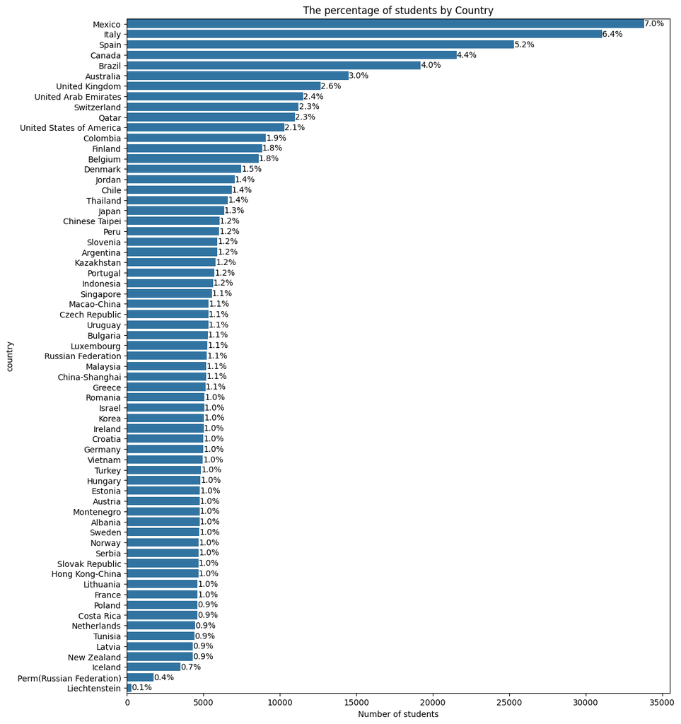

```python
# Set plot dimensions
plt.figure(figsize = [12, 15])

# Set base color
base_color = sb.color_palette()[0]

# Define proportion
country_counts = df_copy['country'].value_counts()
country_order = country_counts.index
n_students = country_counts.sum()

# Plot
sb.countplot(data = df_copy, y = 'country', color = base_color, order = country_order)
plt.title('The percentage of students by Country')
plt.xlabel('Number of students');

# Add percentage text to each bar
for i in range (country_counts.shape[0]):
    count = country_counts[i]
    # Convert count into a percentage, and then into string
    pct_string = '{:0.1f}%'.format(100*count/n_students)
    # Print the string value on the bar.
    plt.text(count+1, i, pct_string, va='center')
```

#### Observation for Question 1

The number of students in each country is not equally represented. The first 10 countries and the last 3 countries move away from 5000 students (1%). 3 countries have highest number of students are Mexico, Italy and Spain. Liechtenstein has the lowest number of participants.

### Question 2: How does the gender distribution look like?

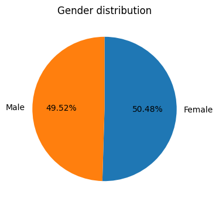

```python
# Set plot dimensions
plt.figure(figsize = [4, 4])

# Plot
gender_count = df_copy['gender'].value_counts()
plt.pie(gender_count, labels = gender_count.index, startangle = 90, counterclock=False, autopct='%1.2f%%')
plt.title('Gender distribution');
```

#### Observation for Question 2

The proportion of female participants is slightly higher.

### Question 3: What is the distribution of educational levels for father and mother?

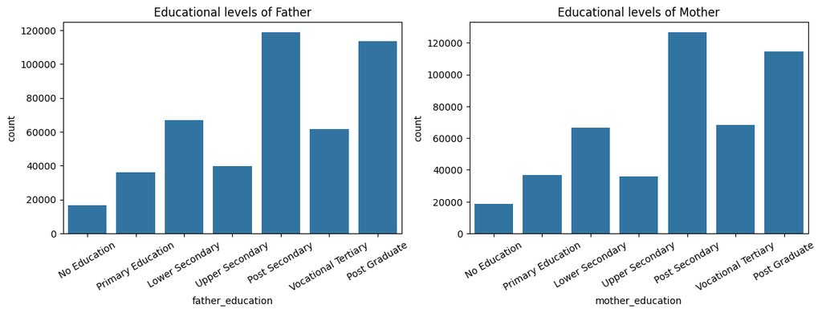

```python
# Set plot dimensions
plt.figure(figsize = [14, 4])

plt.subplot(1, 2, 1)
sb.countplot(data = df_copy, x = 'father_education', color = base_color)
plt.xticks(rotation = 30)
plt.title('Educational levels of Father')

plt.subplot(1, 2, 2)
sb.countplot(data = df_copy, x = 'mother_education', color = base_color)
plt.xticks(rotation = 30)
plt.title('Educational levels of Mother');
```

#### Observations for Question 3

Both parents have a similar distribution of educational levels. The two most popular levels are post-secondary and post-graduate.

### Question 4: Do scores follow a normal distribution?

```python
# Create a function to plot histograms
def histogram (col, binsize, xlabel=None):
    bins = np.arange(0, df_copy[col].max()+binsize, binsize)
    plt.hist(data = df_copy, x = col, bins = bins)
    plt.title('{}'.format(col.replace('_', ' ').title()))
    plt.xlabel(xlabel)
    plt.ylabel('Student Count')
    plt.axvline(x = df_copy[col].median(), color = 'red')
```

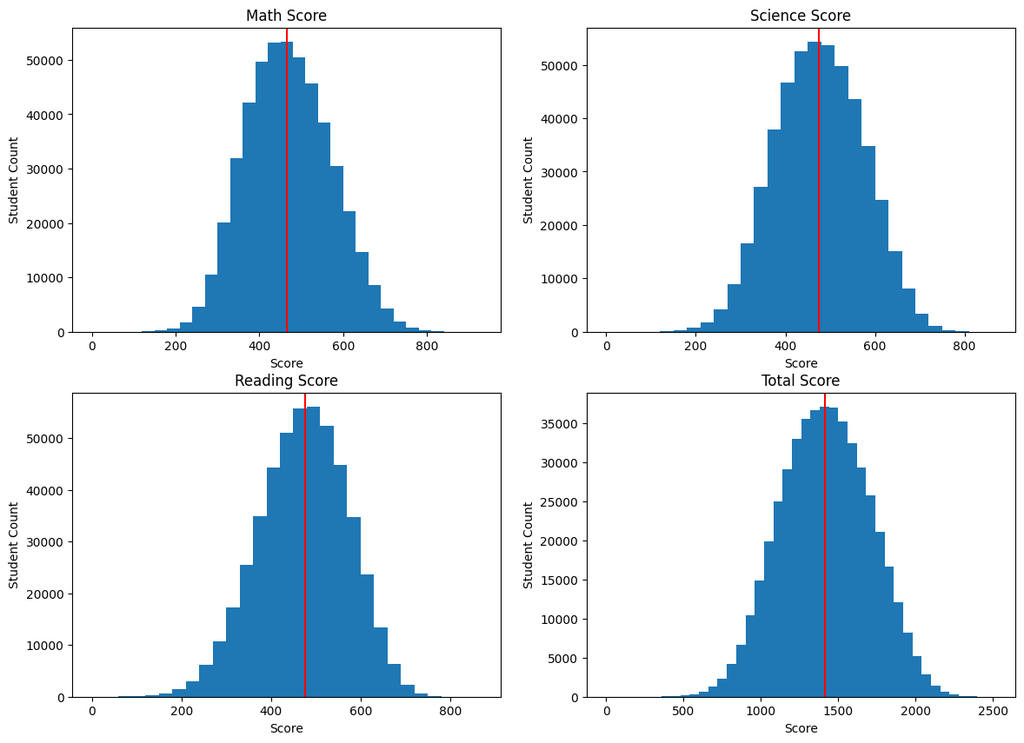

```python
# Set the plot dimensions
plt.figure(figsize = [14, 10])

# Create a dictionary to map positions with columns
scores_dict = {1:'math_score', 2:'science_score', 3:'reading_score', 4:'total_score'}

# Plot
for pos, col in scores_dict.items():
    plt.subplot(2, 2, pos)
    if pos == 4:
        histogram(col, binsize = 60, xlabel = 'Score')
    else:
        histogram(col, binsize = 30, xlabel = 'Score')
```

#### Observation for Question 4

All score distributions are normal. 3 subject distributions have a peak at about 500.

### Quesstion 5: What about the distribution for learning time?

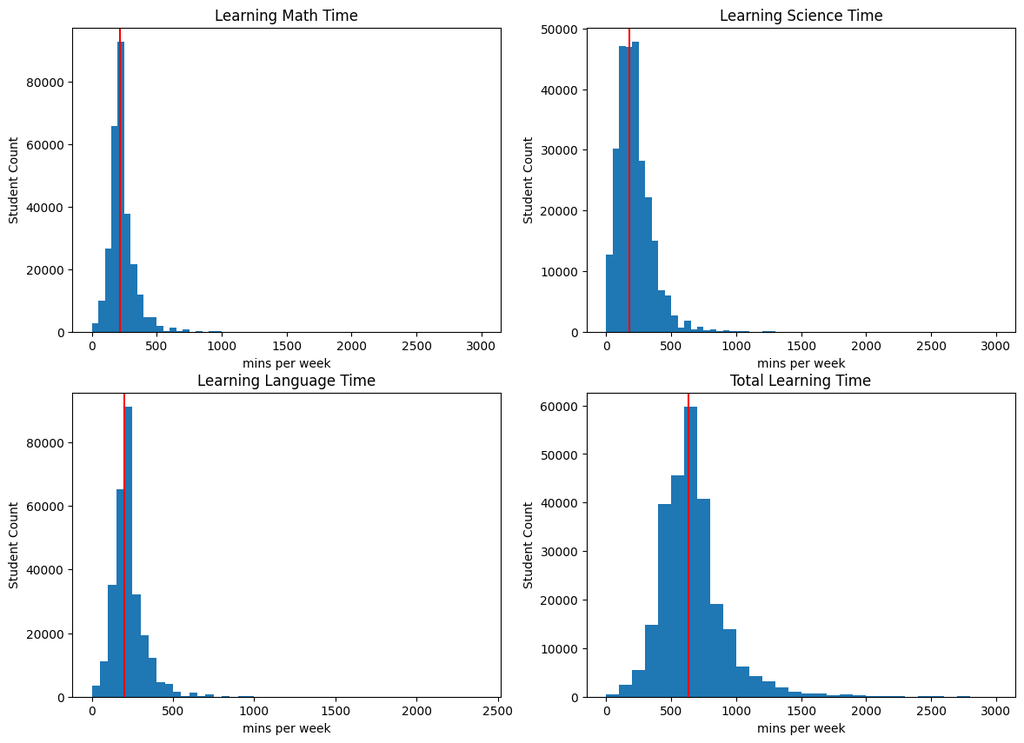

```python
# Set plot dimensions
plt.figure(figsize = [14, 10])

# Create a dictionary to map positions with columns
learning_time_dict = {1:'learning_math_time', 2:'learning_science_time', 3:'learning_language_time', 4:'total_learning_time'}

# Plot all histograms
for pos, col in learning_time_dict.items():
    plt.subplot(2, 2, pos)
    if pos == 4:
        histogram(col, binsize=100, xlabel='mins per week')
    else:
        histogram(col, binsize=50, xlabel='mins per week')
```

Noticed that the x-axis is set far to the left, sugesting some strong outliers on the right. Let's use `xlim` to zoom in the distribution.

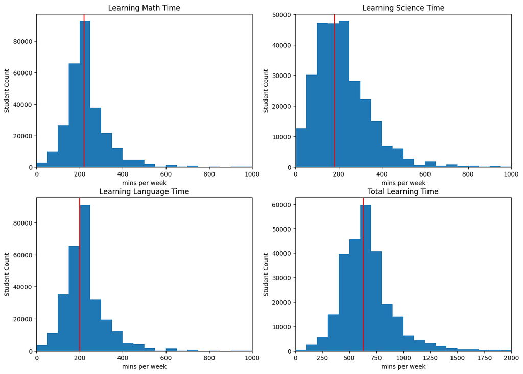

```python
# Set plot dimensions
plt.figure(figsize = [14, 10])

# Plot all histograms
for pos, col in learning_time_dict.items():
    plt.subplot(2, 2, pos)
    if pos == 4:
        histogram(col, binsize = 100, xlabel='mins per week')
        plt.xlim(0, 2000)
    else:
        histogram(col, binsize = 50, xlabel='mins per week')
        plt.xlim(0, 1000)
```

#### Observation for Question 5

All learning time plots are right-skewed.

### Univariate Exploration - Summary

In this part, I split my exploration to 2 groups here:

- Question 1 to 3: categorical variables (country, gender, and educational levels)
- Question 4 to 5: numerical variables (scores and learning time)

There are 65 participating countries in the dataset. I noticed that not all of them are equally represented. So in the bar plot, I added the percentage to see the proportion of students in each contry and found out most countries contributed around 1% (about 5000 students). Mexico has the highest number of interviewed students (7%) while Liechtenstein has the least number of participants (0.1%).

The proportion of female participants is slightly higher though the difference between genders is very small. I wonder if there is any significant difference in the gender distribution if spitting it to OECD and non-OECD. I will explore that in the bivariate part.

For educational levels, both parents follow the same distribution, with the majority having post-secondary and post-graduate education.

I created a function called `histogram` to reducce repetitive code in plotting score distributions. All distributions (Math, Science, Reading and the total) are normally distributed. 3 subject distributions all have a peak at about 500.

For the learning time (mins per week), using the function `histogram` above, I noticed that the x-axis of 4 distrbution (3 subjects and the total) is set far to the left, sugesting some strong outliers on the right. Therefore, I used the `xlim` function to limit those outliers and found out all distributions of learning time are right-skewed. The peak is about 180-220 minutes per week.

## Bivariate Exploration

### Question 6: Is the gender distribution different in OECD or non-OECD countries?

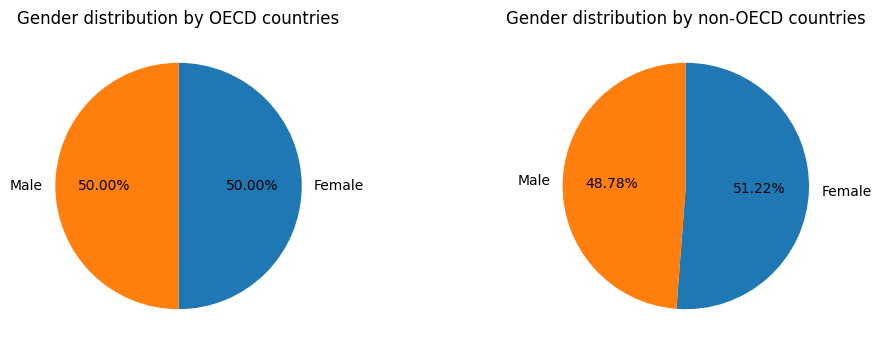

```python
# Filter genders by OECD/non-OECD countries
oecd_gender = df_copy.query('oecd == "OECD"')['gender'].value_counts()
non_oecd_gender = df_copy.query('oecd == "Non-OECD"')['gender'].value_counts()

# Set figure dimensions
plt.figure(figsize=[12, 4])

# Plot
plt.subplot(1,2,1)
plt.pie(oecd_gender, labels = oecd_gender.index, startangle = 90, counterclock=False, autopct='%1.2f%%')
plt.title('Gender distribution by OECD countries')

plt.subplot(1,2,2)
plt.pie(non_oecd_gender, labels = non_oecd_gender.index, startangle = 90, counterclock=False, autopct='%1.2f%%')
plt.title('Gender distribution by non-OECD countries');
```

#### Observation for Question 6

The gender distribution in OECD countries is equally distributed. In non-OECD countries, the percentage of female students is slightly higher.

### Question 7: Does one gender perform better than the other in any category subject?

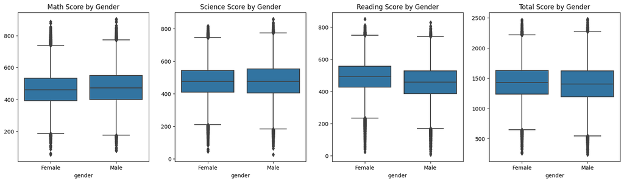

```python
# Set plot dimensions
plt.figure(figsize = [20, 5])

for pos, col in scores_dict.items():
    ax = plt.subplot(1, 4, pos)
    sb.boxplot(data=df_copy, x='gender', y=col, color=base_color)
    plt.title('{} by Gender'.format(col.replace('_', ' ').title()))
    ax.set_ylabel(None)
```

#### Observation for Question 7

Overall, male and female students have the similar total score. Female students have better performance in Reading while male students perform slightly better in Math. Both genders perform equally well in Science, although male students have a larger interquartile range.

### Question 8: Do students in OECD countries perform better than students in non-OECD countries ?

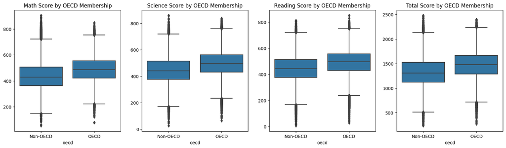

```python
# Set plot dimensions
plt.figure(figsize = [20, 5])

# Plot
for pos, col in scores_dict.items():
    ax = plt.subplot(1, 4, pos)
    sb.boxplot(data=df_copy, x='oecd', y=col, color=base_color)
    plt.title('{} by OECD Membership'.format(col.replace('_', ' ').title()))
    ax.set_ylabel(None)
```

#### Observation for Question 8

OECD countries have better performance in all subjects than non-OECD countries.

### Question 9: How does the performance in each subject by country look like?

```python
def rank_means(col):
    # Set figure dimensions
    plt.figure(figsize = [14, 15])

    # Calculate mean of total score by country
    mean_vars = df_copy.groupby('country')[col].mean().sort_values(ascending=False)

    # Plot
    sb.barplot(data=df_copy, x=col, y='country', color=base_color, order=mean_vars.index, errorbar=None)
    plt.title('{} by Country'.format(col.replace('_', ' ').title()))
    plt.xlabel('Mean of {}'.format(col.replace('_', ' ')))

    # Add labels
    for i in range (mean_vars.shape[0]):
        count = mean_vars[i]
        # Convert count into string
        count_str = '{:.1f}'.format(count)
        # Print the string value on the bar
        plt.text(count+1, i, count_str, va='center')
```

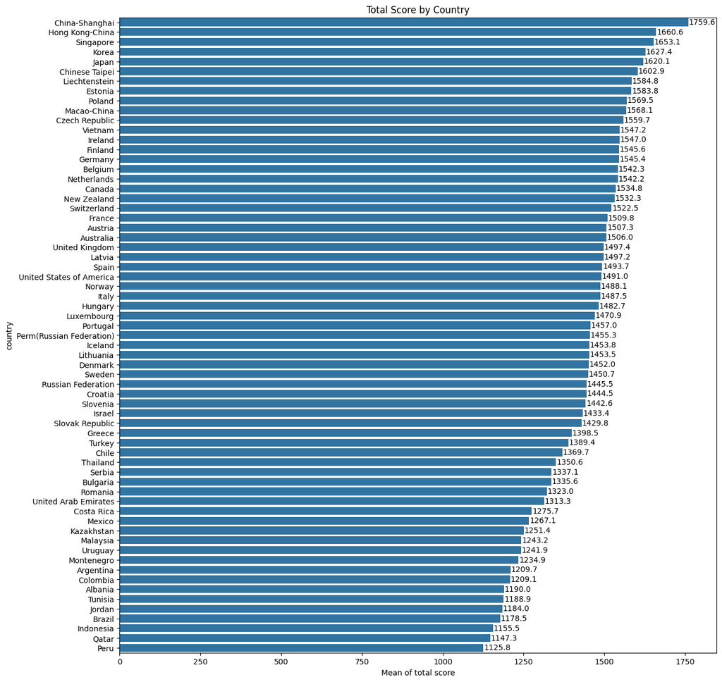

```python
# Total score by country
rank_means('total_score')
```

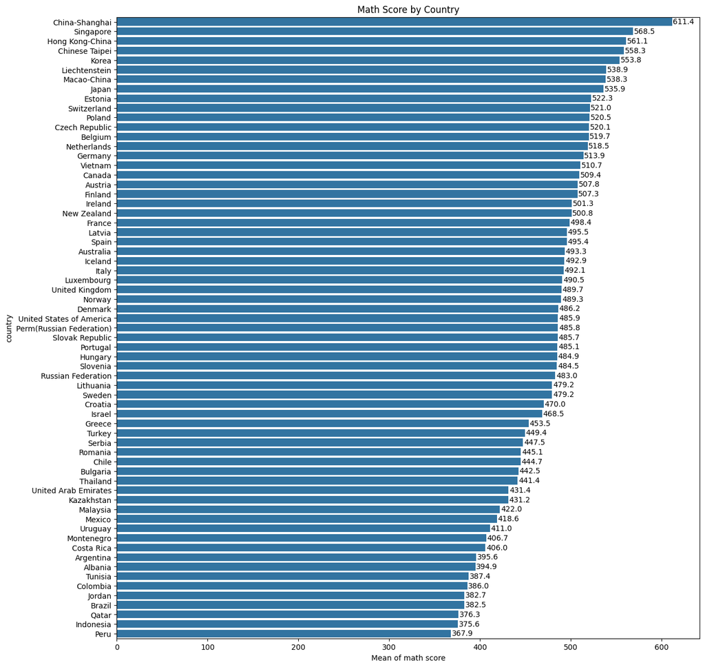

```python
# Math score by country
rank_means('math_score')
```

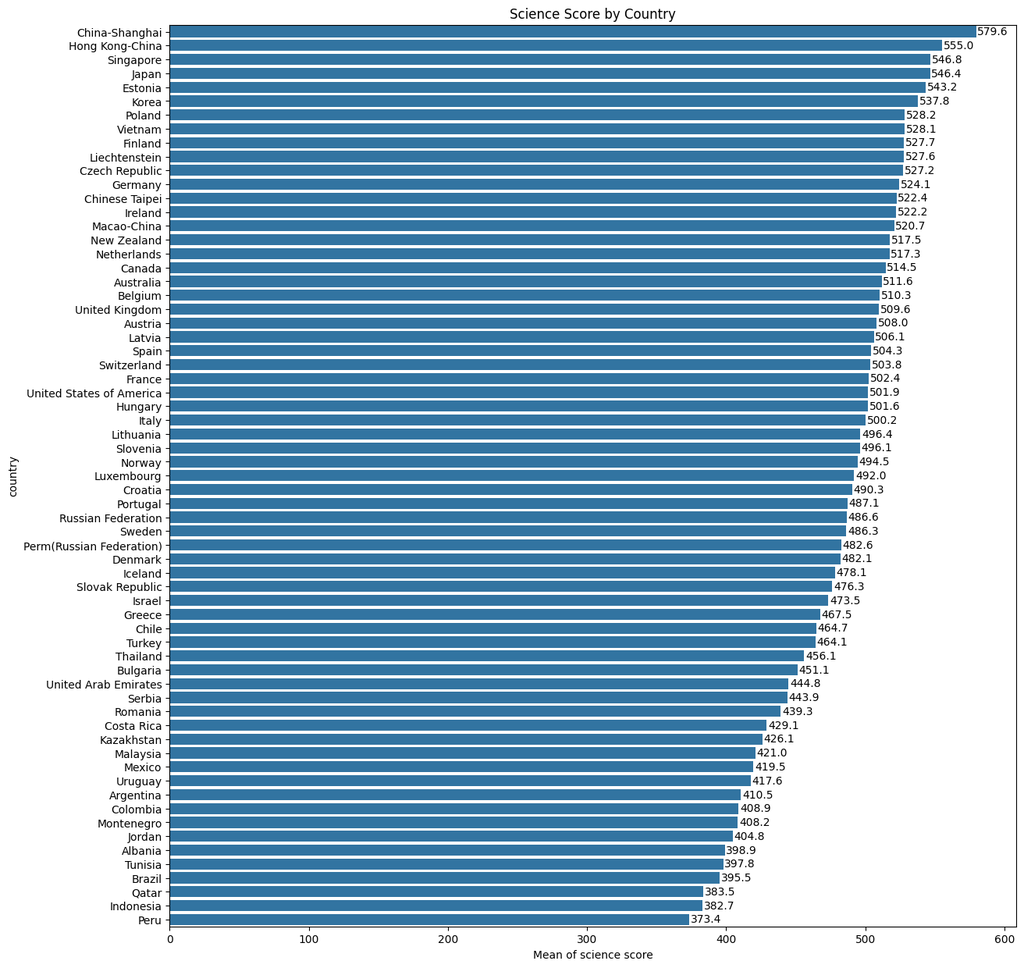

```python
# Science score by country
rank_means('science_score')
```

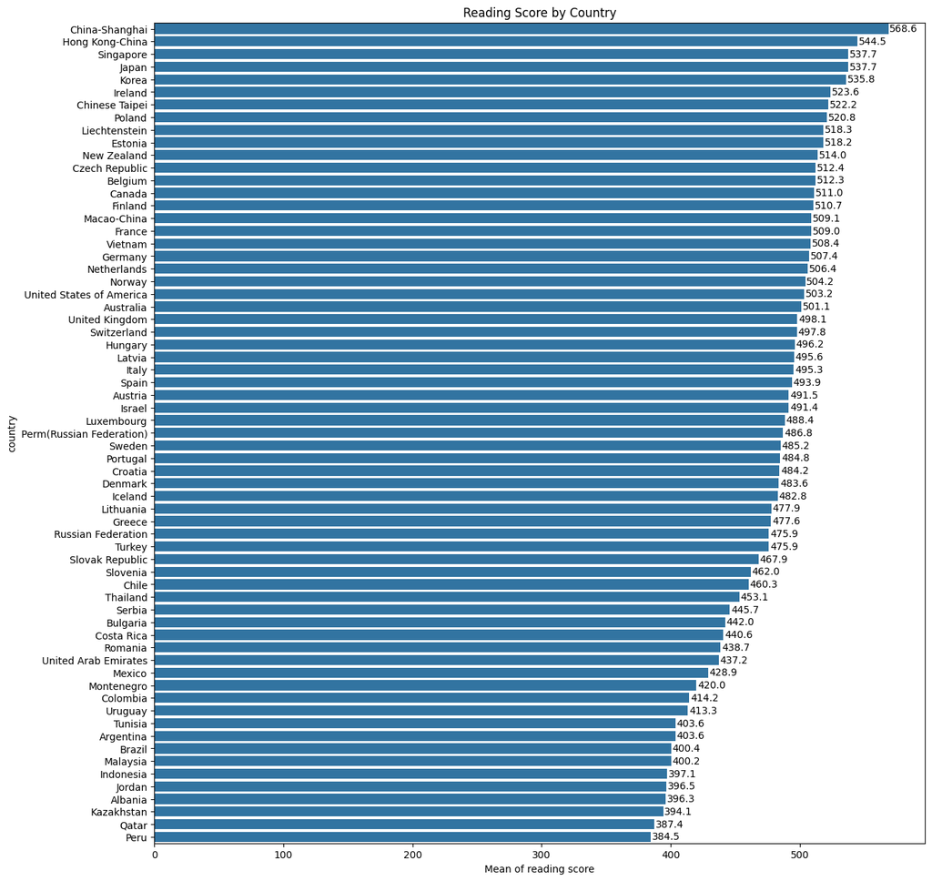

```python
# Reading score by country
rank_means('reading_score')
```

#### Observation for Question 9

Overall, China-Shanghai has the best performance while Peru has the worst performance. Top 10 highest scores in 3 subjects are mostly from Asia, though their ranks are slightly different from Math, Science to Reading. 3 non-Asian countries on top 10 are Liechtenstein, Estonia and Poland. Interestingly, the number of Liechtenstein students only account for 0.1% of our dataset, which is the lowest. (Question 1).

### Question 10: Does longer learning time lead to higher performance?

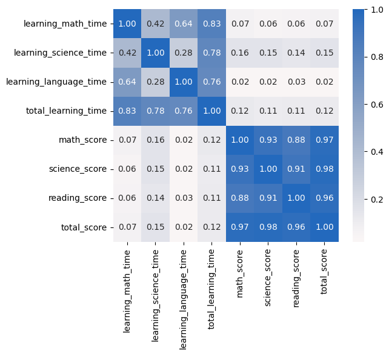

```python
learning_time_scores = ['learning_math_time', 'learning_science_time', 'learning_language_time', 'total_learning_time',
                      'math_score', 'science_score', 'reading_score', 'total_score']

# Set figure dimentsions
plt.figure(figsize=[6,5])

# View the correlation coefficient among all learning time and score variables
sb.heatmap(df_copy[learning_time_scores].corr(), annot=True, fmt='.2f', cmap='vlag_r', center=0);
```

#### Observation for Question 10

With low correlation coefficients, learning time and scores don't correlate with each other, meaning longer learning time doesn't lead to higher performance. Nevetheless, it seems like scores are correlated to each other. Let's check that using the scatter plot.

### Question 11: Are scores correlated to each other?

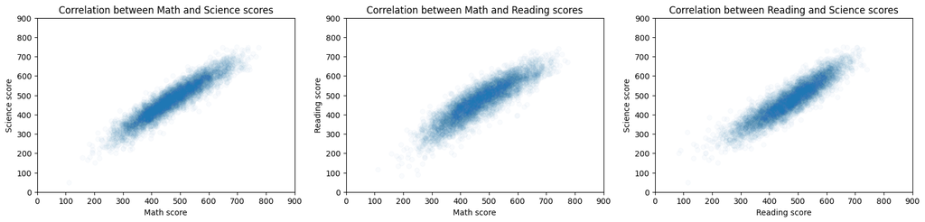

```python
# Create a sample
df_sample = df_copy.sample(5000)

# Set figure dimensions
plt.figure(figsize = [20, 4])

# Plot
ax2 = plt.subplot(1, 3, 1)
plt.scatter(data = df_sample, x = 'math_score', y = 'science_score', alpha = 1/40);
plt.xlabel('Math score')
plt.ylabel('Science score')
ax2.set_title('Correlation between Math and Science scores');


ax1 = plt.subplot(1, 3, 2)
plt.scatter(data = df_sample, x = 'math_score', y = 'reading_score', alpha = 1/40);
plt.xlabel('Math score')
plt.ylabel('Reading score')
ax1.set_title('Correlation between Math and Reading scores');


ax3 = plt.subplot(1, 3, 3)
plt.scatter(data = df_sample, x = 'reading_score', y = 'science_score', alpha = 1/40);
plt.xlabel('Reading score')
plt.ylabel('Science score')
ax3.set_title('Correlation between Reading and Science scores');


# Set the same axis ranges for all plots
plots = [ax1, ax2, ax3]
for ax in plots:
    ax.set_xlim([0, 900])
    ax.set_ylim([0, 900])
```

#### Observation for Question 11

All plots show a positive correlation, suggesting that if a student performs well in either of the 3 subjects, he or she also performs well in the other two. Noticeably, the graph about Math and Science have highest level of density, so these two subjects has the strongest correlation.

### Question 12: Are educational levels of parents correlated to each other?

```python
# Create a pivot table with the count for both education variables
education_parents = df_copy.groupby(['father_education','mother_education']).size().reset_index(name='count')
pivot_education = education_parents.pivot(index=['father_education'],columns=['mother_education'], values='count')
pivot_education
```

| mother_education father_education | No Education | Primary Education | Lower Secondary | Upper Secondary | Post Secondary | Vocational Tertiary | Post Graduate |
| --- | --- | --- | --- | --- | --- | --- | --- |
| No Education | 7036 | 3643 | 2412 | 278 | 1682 | 497 | 595 |
| Primary Education | 4372 | 14729 | 7378 | 834 | 4830 | 1440 | 1654 |
| Lower Secondary | 2645 | 7688 | 27046 | 4050 | 13744 | 4828 | 5685 |
| Upper Secondary | 377 | 905 | 4803 | 16742 | 8477 | 3733 | 4062 |
| Post Secondary | 2034 | 4657 | 12648 | 5685 | 62426 | 12107 | 17776 |
| Vocational Tertiary | 569 | 1525 | 4394 | 2944 | 11610 | 26985 | 12976 |
| Post Graduate | 708 | 1570 | 4674 | 3349 | 18435 | 15744 | 67916 |

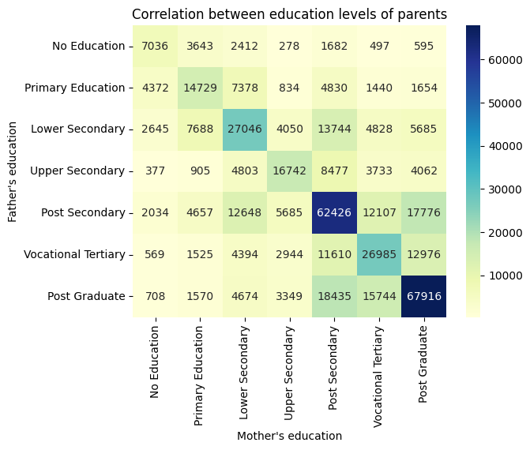

```python
# Plot
ax = sb.heatmap(pivot_education, annot=True, fmt='d', cmap='YlGnBu')
ax.set_title('Correlation between education levels of parents')
ax.set_xlabel('Mother\'s education')
ax.set_ylabel('Father\'s education');
```

#### Observation for Question 12

The diagonal in the heatmap above shows a high correlation between father and mother's education. Parents tend to have same educational levels.

### Question 13: Does parents' education affect their children's academic performance?

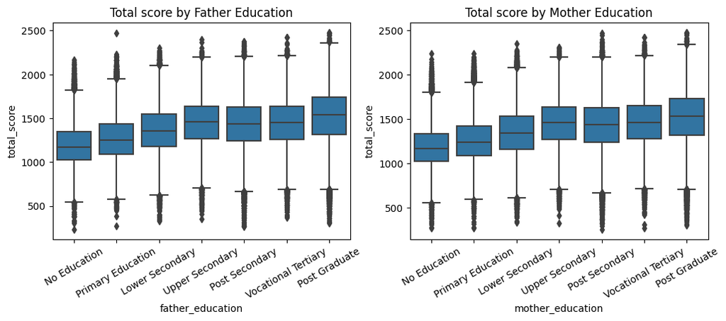

```python
plt.figure(figsize=[12,4])

plt.subplot(1,2,1)
sb.boxplot(data = df_copy, x = 'father_education', y = 'total_score', color=base_color)
plt.xticks(rotation = 30)
plt.title('Total score by Father Education')

plt.subplot(1,2,2)
sb.boxplot(data = df_copy, x = 'mother_education', y = 'total_score', color=base_color)
plt.xticks(rotation = 30)
plt.title('Total score by Mother Education');
```

#### Observation from Question 13

From the two plots above, we can see a similar trend between both parents with their children's total score. Students whose parents have higher level of education are more likely to perform better. Notably, for parents with educational levels from Upper Secondary to Vocational Tertiary, the difference in their children's performance is less significant.

### Question 14: Is learning time different in OECD and non-OECD countries?

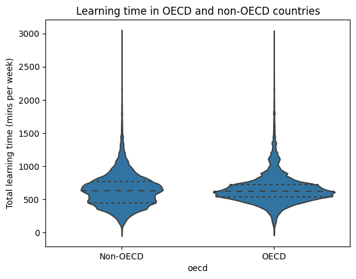

```python
sb.violinplot(data=df_copy, x='oecd', y='total_learning_time', color=base_color, inner='quartile')
plt.title('Learning time in OECD and non-OECD countries')
plt.ylabel('Total learning time (mins per week)');
```

#### Observation for Question 14

Despite of some outliers, the overall learning time in non-OECD countries is nearly same as that in OECD countries. However, the distribution of learning time in non-OECD is more spread.

### Question 15: Does one gender has longer learning time than the other?

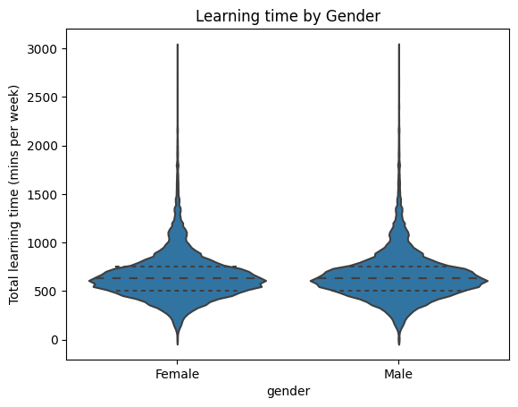

```python
sb.violinplot(data=df_copy, x='gender', y='total_learning_time', color=base_color, inner='quartile')
plt.title('Learning time by Gender')
plt.ylabel('Total learning time (mins per week)');
```

#### Observation for Question 15

There is no difference in the learning time between female and male students.

### Bivariate Exploration - Summary

In this part, I want to discover which factors may affect student's performance and their study time.

When splitting genders into OECD and non-OECD countries, I noticed that gender distribution in OECD countries is equally distributed, whereas the proportion of female participants in non-OECD countries is slightly higher (51,22%). While females have better performance in Reading, males perform slightly better in Math. Both genders have similar performance in Science.

As expected, OECD countries have better performance in all Math, Science and Reading than non-OECD countries. I wonder if there is any difference if we continue breaking it to each gender, so I will explore that in the multivariate part.

To rank the mean of total score and each subject's score, I created a function called `rank_means`. Overall, China-Shanghai has the best performance while Peru has the worst performance. Top 10 highest scores in 3 subjects are mostly from Asia, though their ranks are slightly different from Math, Science to Reading. 3 non-Asian countries on top 10 are Liechtenstein, Estonia and Poland. Interestingly, the number of Liechtenstein students only account for 0.1% of our dataset, which is the lowest (Question 1).

I wonder if longer learning time may result in higher performance, so I created a correlation heatmap of among all learning time and score variables. I found out longer learning time doesn't lead to higher performance, but at the same time, I noticed that scores seem to correlate to each other because of high correlation coefficients. This was then confirmed using the scatter plot in Question 11, which means if a student performs well in either of Math, Science or Reading, he or she also performs well in the other two. But in general, Math and Science has the strongest correlation.

Using a heatmap to plot the group count of mother and father education level, I noticed that parents tend to have same educational levels. This is also reflected in two box plots of question 13 when I saw a similar trend between both parents with their children's total score. Students whose parents have higher level of education are more likely to perform better. Neverthesless, for parents with educational levels from Upper Secondary to Vocational Tertiary, the difference in their children's performance is less significant.

There is no significant difference in learning time between female and male students, and the same goes for those coming from OECD or non-OECD countries.

## Multivariate Exploration

### Question 16: Is there any difference in the performance of students by gender and OECD countries?

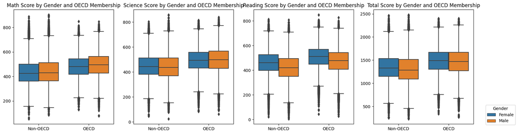

```python
# Set figure dimensions
plt.figure(figsize=[20,5])

# Plot
for pos, col in scores_dict.items():
    ax = plt.subplot(1, 4, pos)
    sb.boxplot(data=df_copy, x='oecd', y=col, hue='gender')
    plt.title('{} by Gender and OECD Membership'.format(col.replace('_', ' ').title()))
    ax.set(xlabel=None, ylabel=None)
    if pos == 4:
        ax.legend(title="Gender", loc='center left', bbox_to_anchor=(1.1, 0.08))
    else:
        ax.get_legend().remove()
```

### Question 17: Is there any difference in the learning time of students by gender and OECD countries?

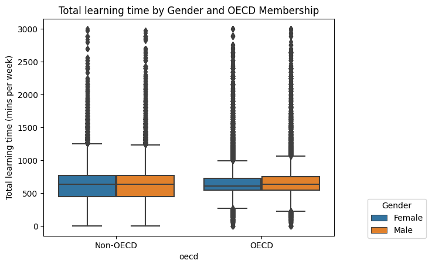

```python
sb.boxplot(data=df_copy, x='oecd', y='total_learning_time', hue='gender')
plt.title('Total learning time by Gender and OECD Membership')
plt.legend(title="Gender", loc='center left', bbox_to_anchor=(1.1, 0.08))
plt.ylabel('Total learning time (mins per week)');
```

#### Observation for Question 17

In question 14 and 15, when evaluating the relationship between learning time and gender or OECD countries individually, there is no difference. But when combining all variables together in the visualization above, we can see that:

- In non-OECD countries, females and males have the same learning time
- In OECD countries, males have longer learning time than females
- The females' learning time in non-OECD countries is slightly longer than that of females from OECD countries

### Multivariate Exploration - Summary

In this part, I only used 2 box plots to deep dive into the relationship between student performance or learning time with gender and OECD membership.

For the learning time, while females and males have the same learning time in non-OECD countries, males have longer learning time than females in OECD countries. Interestingly, the learning time of female students in non-OECD countries is slightly longer than those from OECD countries.

## Conclusions

This project aims to explore whether certain background factors can affect students' academic performance and how much time they spend learning.

With a large and complex dataset like PISA 2012, I only focused on some features of interest including country of residence, OECD membership, student's gender, parents' education level; as well as 15 plausible values for Math, Science, Reading along with three corresponding columns for learning time. According to the PISA 2012 Technical Report, plausible values are not real test scores but estimated numbers drawn from the similar distributions that could represent the individual tests. Since various factors can influence these scores, it's best to take the average for each subgroup.

The Univariate Exploration lets me analyze each variable on its own and understand how the data are distributed. I noticed that all scores follow a normal distribution, while learning time's distributions are skewed to the right. The distribution of genders is roughly equal, and most parents in the dataset have post-secondary or post-graduate education. Regarding countries, while most of them account for 1% of the dataset, some have significantly larger representation (like Mexico, at 7%) or smaller representation (like Liechtenstein, at 0.1%).

In the Bivariate Exploration, I explore the relationship between each independent variable and scores or learning time. Certain variables do have an impact on scores, such as OECD membership, country of residence, gender, and parents' education level. I also discovered that longer learning time doesn't necessarily lead to better performance. Notably, scores are correlated with each other, and parents often have the same educational level.